# Replication of ‘The Psychology of the Monty Hall Problem’ by Krauss and Wang (2003, Journal of Experimental Psychology)

John Wilcox (wilcoxje@stanford.edu)

December 17, 2018

## Links

Link to the GitHub repository: https://github.com/psych251/krauss2003

Link to the original paper: https://github.com/psych251/krauss2003/blob/master/original_paper/krauss2003.pdf

Link to the Qualtrics survey: https://stanforduniversity.qualtrics.com/jfe/form/SV_beA2tfPyXz83Otv

Link to preregistration: https://osf.io/n3abr/

## Introduction

My PhD research focuses on the question of how humans should assign probabilities in various contexts, all with the hope to inform practical interventions to improve human reasoning. Studies show that the so-called “Monty Hall problem” is one context where humans frequently assign incorrect probabilities. This is an important context since it tests one’s capacity to reason properly about likelihoods, a capacity which is central to reasoning about many topics in scientific, medical and everyday settings. Consequently, this paper hopes to partially replicate a promising procedure (experiment 1) for inculcating correct reasoning about the Monty Hall problem.

The procedure administers two questionnaires to participants in an experimental and a control condition. Participants in the control condition complete a questionnaire which asks for participants’ responses to a standard version of the Monty Hall problem. Participants in the experimental condition complete a questionnaire about the “Guided intuition version” of the Monty Hall problem. Here, participants are guided to the correct solution to the Monty Hall problem with questions which encourage them: 1) to consider the problem from the fully informed perspective of Monty Hall, 2) to consider all possible arrangements of where the prize might be, 3) to count the frequencies with which a response strategy yields the optimal outcome and 4) to ignore the specifics of which particular door is opened by specifying merely that some door was opened and revealed a goat.

## Methods

Participants will be recruited via Amazon Mechanical Turk.

### Power Analysis

For two groups with proportions of 3% and 38%:

- 38 respondents are needed to achieve 80% power (with respondents evenly allocated between groups)
- 46 respondents are needed to achieve 90% power (with respondents evenly allocated between groups)
- 58 respondents are needed to achieve 95% power (with respondents evenly allocated between groups)

### Planned Sample

The original study featured three groups of participants recruited from various German universities. There were 67 participants in the control group and 34 participants in the experimental condition (bearing in mind that another 34 participants were also included in an alternative experimental group which is not the focus of replication for this study).

To ensure that the replication study is close to the original study, participants will be selected so as to inlude only people who have graduated from high school.

Some participants may have prior familiarity with the Monty Hall problem. Such participants will be omitted from the study with pre-test and post-test approaches.

The pre-test approach will ask participants to indicate whether they are familiar with the Monty Hall problem prior to receiving the (modified) instructions in appendix A or B. The limitation with this approach is that it introduces a potential source of error into the study: participants may indicate that they are not familiar with the problem merely so that they can receive the monetary reward of completing the task on Mechanical Turk, and their prior familiarity may bias the results. In an attempt to control for this, participants will be asked a list of questions so that they are less likely to tell which question could prevent their participation on the task.

The post-test approach asks participants to indicate whether they are familiar with the Monty Hall through the instructions in appendix A or B. In particular, the last item on the instructions asks participants to “Please also tell us if you were already familiar with this game… and knew what the correct answer should be”

The post-test approach can avoid the earlier source of bias.

### Materials

Materials used for this study will include two versions of instructions: the control group instructions and the so-called “Guided Intuition instructions”. These are reproduced in full in appendices A and B respectively. The guided intuition version incorporates the four features which Krauss and Wang believe facilitate good reasoning.

Two minor modifications will be made to the materials:

- First, the request for justification will omit the statement that “You may use sketches, etc., to explain your answer” as the online testing environment would not provide for that capacity.
- Second, an attention check will be included, asking participants how many doors are in the problem.

### Procedure

Participants will be randomly assigned to the control and the experimental condition, where they will be instructed to complete the tasks outlined in the respective appendices via Amazon Mechanical Turk.

Participants will be paid $0.97 amount for completion of the task, and they will have up to 3 hours to complete the task (although I expect responses to take about 8 minutes on average).

### Analysis Plan

Respondents who indicated prior familiarity and who failed the attention check will be excluded from the analysis.

The original study reports various statistical measures, but the one of primary importance concerns the difference in correct justifications between the groups. To clarify, a participant would give a correct justification for their answer to the Monty Hall problem when they both provided the correct probability of switching doors (2/3) and this probability assignment was, in the words of the original authors, “comprehensibly derived” (11).

Such assignments could be comprehensibly derived in two ways:

1.Specifying the probabilities via use of Bayes’s theorem (7)

2.Counting the frequency with which the prize is one among various possible outcomes of the Monty Hall problem (two examples of which are provided on page 5)

The justifications will be extracted to a separate Excel file where justifications will be coded as correct or incorrect, all while being blind to which justifications are from the experimental or control conditions. The coding will then be transferred back to the main analysis dataframe. This may yield distinct proportions of correct justifications for the experimental and control conditions.

Following the original study’s protocol, the difference between such proportions will be measured using Cohen’s h and statistical significance will be calculated using Fisher’s exact test. Cohen’s h is then the key statistic of interest for this replication.

### Differences from Original Study

There are several salient differences between this replication study and the original experiment:

Pictorial justifications: In the original study, participants were allowed to visually represent their justifications for their responses in various formats, such as drawings of doors. For technical reasons, this study will not enable participants to draw such pictures, but it is expected that this should have a negligible impact on the proportion of correct justifications given or how they are coded.

Experimental setting: The original study brought students into the laboratory to complete their tasks, unlike the current study in which participants may respond through Amazon Mechanical Turk. Consequently, respondents may have been more likely to give more attention to the reasoning task since they are in an environment created for that sole purpose and the environment also includes the physical presence of an experimenter. In contrast, since Mechanical Turkers are left to their own devices, it is possible that the may rush through the task, thereby reducing the proportion of correct justifications or the clarity with which justifications are articulated. There is no definitive evidence about how great a risk this poses, but suspect it would be negligible, at least for the purposes of testing a substantial effect of some size.

Coding of correct justifications: Unlike the previous study, a different coder (the present author) will code the justifications as correct or incorrect according to the criteria specified in the original paper. The results could be influenced by imperfect inter-rater reliability. However, it seems to me that the criteria for what qualifies as a correct justification are fairly straight-forward, comprehensible and uncontroversial, and so I suspect that the coders in the original and replication studies would likely have high or perfect agreement.

### Methods Addendum (Post Data Collection)

The actual methodology of this study departed from the initial design plan in several ways concern data collection.

Only three inidividuals responded to the online survey during the first three days when the initial plan was executed. This was too slow. It is not certain why so few people replied, but in an attempt to increase the number of respondents, the task qualifications were removed. In particular, the task qualifications on MTurk were removed so that the task was visible to people aside from just US high school graduates or those who indicated no prior familiarity with the problem.

Instead, participants merely indicated their familiarity with the Monty Hall problem on the survey form and were consequently excluded from analysis.

Due to resource limitations, the study then sampled only 42 participants, but only 19 of these both passed the attention check and indicated that they were not already familiar with the problem.

The resulting data was then unevenly distributed between the control and experimental conditions: the control condition had 8 valid responses and the experimental condition had 11.

Consequently, the actual data collection featured a small sample size and more uneven distribution of data than initially planned.

## Results

### Data preparation

```r
###Data Preparation

# Loading the anonymized data (with coding about correct justifications added in the original datafile)

dataedit <- read.csv("C:/Users/john-/krauss2003/data/anonymizedfinaldata.csv", comment.char="#")


#Installing and loading relevant packages

# install.packages("tidyverse")
library("tidyverse")
# Renaming columns in datafile to shorter variables titles

data_renamed = dataedit %>% dplyr::rename(
  experimental_switch = What.should.the.contestant.therefore.do.,
  control_switch = After.Monty.Hall.has.opened.a..goat.door...what.should.you.do.,
  familiarity = Please.also.tell.us.if.you.were.already.familiar.with.this.game.,
  attentioncheck = In.the.earlier.scenario..how.many.doors.were.there.in.total..including.either.opened.or.unopened.doors..)



#Removing missing values and excluding people who failed the attention check or were familiar with the game

data_gathered = data_renamed %>% gather(condition, switch, c(experimental_switch, control_switch)) %>%
  filter(switch!="") %>%
  filter(!is.na(switch)) %>%
  filter(attentioncheck =="3 doors in total") %>%
  filter(familiarity == "I was not familiar with this game")


#Recoding variables so the meaning of the values is clearer


data_recoded = data_gathered %>%
  mutate(condition = recode(condition, "experimental_switch"="experimental", "control_switch"="control"))
```

### Confirmatory analysis

```r
###Analysis


#Calculating the proportions of correct justifications given in the control and experimental conditions given

table <- with(
  data_recoded,
  table(correctjustification, condition))


#Calculating Cohen's h test

# install.packages("pwr")
library(pwr)


# h <- ES.h(
#   (table["correct", "control"]/
#      (table["correct", "control"] + table["incorrect", "control"])),
#   (table["correct", "experimental"]/
#       (table["correct", "experimental"] + table["incorrect", "experimental"]))
# )

## Note: ES.h cannot calculate the h when two proportions of 0% are given (as is the case in this study).Consequently, the h value is 0 given that there is no difference, but this value was not computed via the above code.

#Calculating the p value with Fisher's exact test

test <-  fisher.test(as.matrix(table))

# Displaying results from the above calculations

table
```

```
##                     condition
## correctjustification control experimental
##                            0            0
##            incorrect       8           11
```

```r
# h -- commented out since h cannot be calculated in this case
test
```

```
##
##  Fisher's Exact Test for Count Data
##
## data:  as.matrix(table)
## p-value = 1
## alternative hypothesis: true odds ratio is not equal to 1
## 95 percent confidence interval:
##    0 Inf
## sample estimates:
## odds ratio
##          0
```

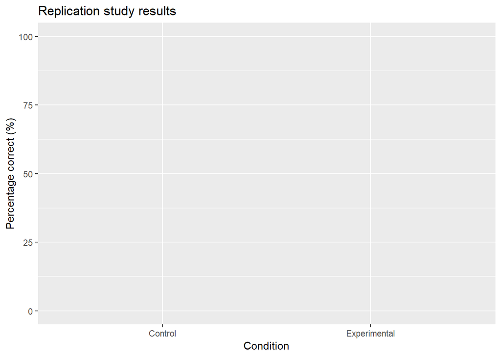

```r
# Plots of results

library(ggplot2)

#Plot of the percentage of correct justifications between the conditions -- from the replication study

ggplot(data = data_recoded, aes(x = condition, y=100*(correctjustification == "correct"))) + geom_bar(stat="summary", fun.y=mean) + labs(title = "Replication study results", x = "Condition", y = "Percentage correct (%)") + ylim(0, 100) +
  scale_x_discrete(breaks=c("control", "experimental"),
                          labels=c("Control", "Experimental"))
```

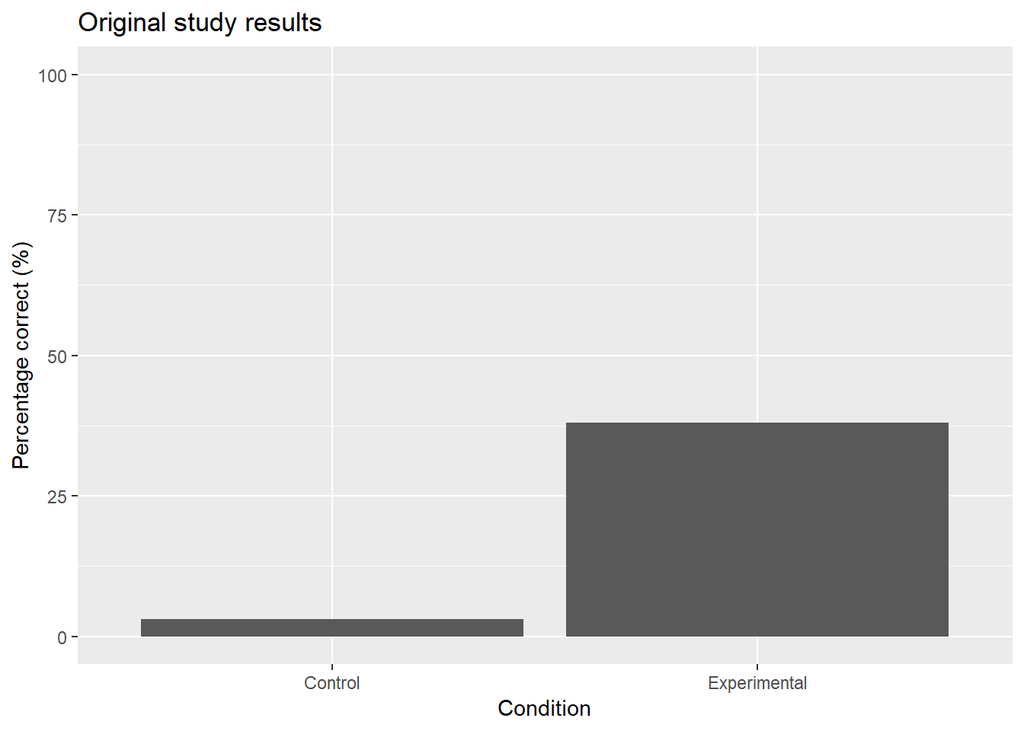

```r
#The corresponding plot from the original study

original = data.frame(Condition=c("A","B"),
                      Percentage=c(3, 38))

ggplot(data=original, aes(x=Condition, y=Percentage)) +
       geom_bar(stat="identity") +
         scale_x_discrete(breaks=c("A", "B"),
                          labels=c("Control", "Experimental")) + ylim(0, 100) +
       labs(title = "Original study results", x = "Condition", y = "Percentage correct (%)")
```

### Exploratory analyses

Exploratory analyses were conducted to see whether the experimental intervention had a significant effect on the number of correct decisions to switch.

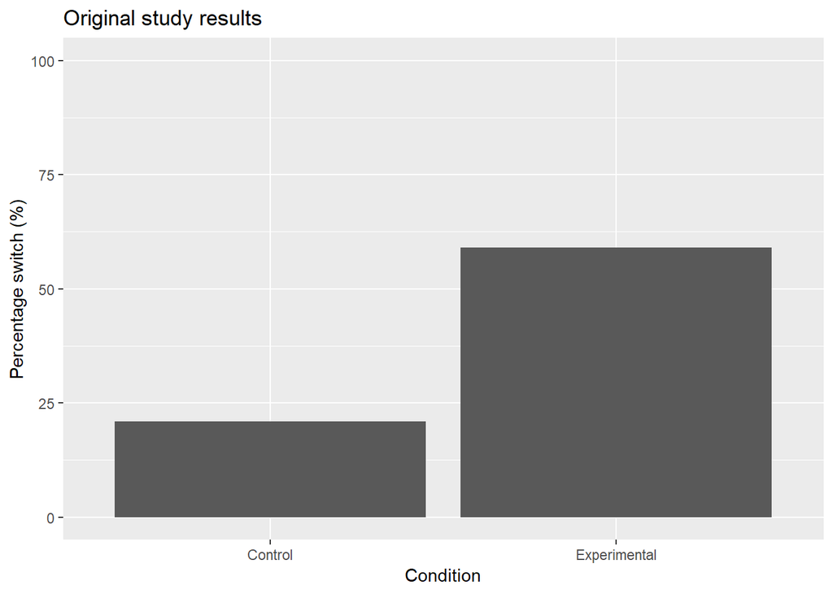

```r
###Analysis


#Plot of correct decisions to switch from the original study

original = data.frame(Condition=c("A","B"),
                      Percentage=c(21, 59))

ggplot(data=original, aes(x=Condition, y=Percentage)) +
       geom_bar(stat="identity") +
         scale_x_discrete(breaks=c("A", "B"),
                          labels=c("Control", "Experimental")) + ylim(0, 100) +
       labs(title = "Original study results", x = "Condition", y = "Percentage switch (%)")
```

```r
#Data on switching

table2 <- with(
  data_recoded,
  table(switch, condition))

h <- ES.h(
  (table2["switch", "control"]/
     (table2["switch", "control"] + table2["stay", "control"])),
  (table2["switch", "experimental"]/
      (table2["switch", "experimental"] + table2["stay", "experimental"]))
)

test2 <-  fisher.test(as.matrix(table2))

# Table displaying counts of switching vs. staying among the conditions

table2
```

```
##         condition
## switch   control experimental
##   stay         5            4
##   switch       3            7
```

```r
# Proportions displaying differences in switching between the groups

  (table2["switch", "control"]/
     (table2["switch", "control"] + table2["stay", "control"]))
```

```
## [1] 0.375
```

```r
  (table2["switch", "experimental"]/
      (table2["switch", "experimental"] + table2["stay", "experimental"]))
```

```
## [1] 0.6363636
```

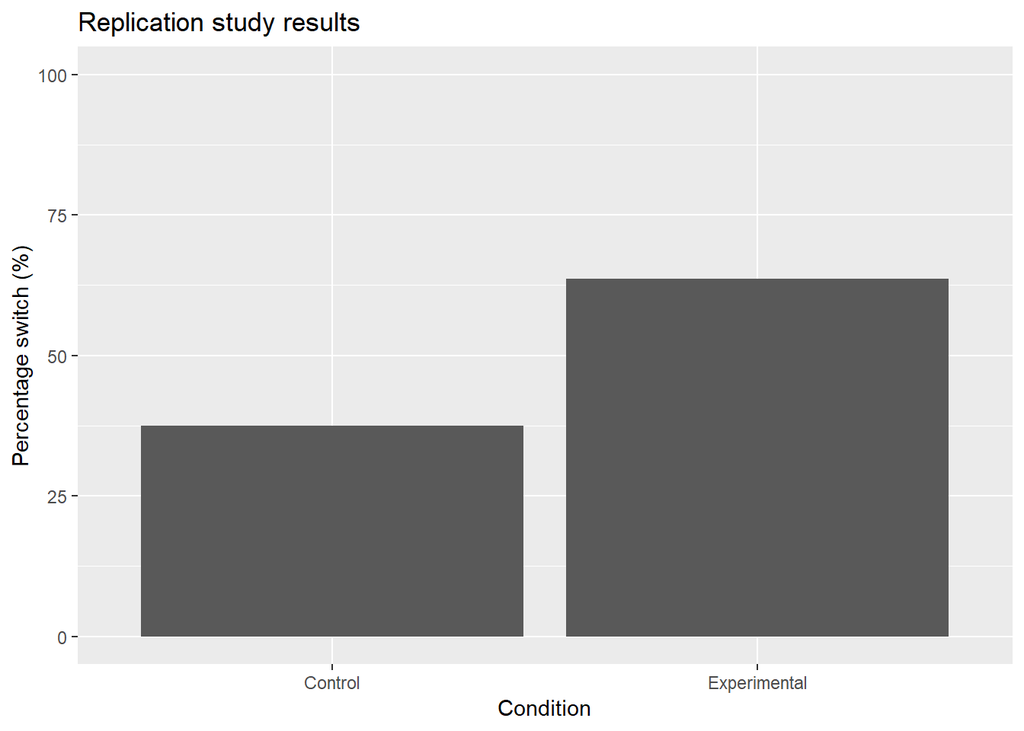

```r
ggplot(data = data_recoded, aes(x = condition, y=100*(switch == "switch"))) + geom_bar(stat="summary", fun.y=mean) + labs(title = "Replication study results", x = "Condition", y = "Percentage switch (%)") + ylim(0, 100) +
  scale_x_discrete(breaks=c("control", "experimental"),
                          labels=c("Control", "Experimental"))
```

```r
# Test of statistical significance between the groups

test2
```

```
##
##  Fisher's Exact Test for Count Data
##
## data:  as.matrix(table2)
## p-value = 0.3698
## alternative hypothesis: true odds ratio is not equal to 1
## 95 percent confidence interval:
##   0.3196802 28.8861681
## sample estimates:
## odds ratio
##    2.74899
```

```r
# Data on experimental manipulation:

table3 <- with(
  data_renamed,
  table(data_renamed$....if.she.he.switches.to.the.last.remaining.door...In.____.out.of.3.cases..Fill.in.the.blank.below., familiarity))

table3
```

```
##            familiarity
##                I was familiar with this game
##              4                            15
##   1          0                             3
##   1.5        0                             1
##   2          0                             3
##   GOAT DOOR  0                             1
##            familiarity
##             I was not familiar with this game
##                                             8
##   1                                         6
##   1.5                                       0
##   2                                         5
##   GOAT DOOR                                 0
```

## Discussion

### Summary of Replication Attempt

This study did not replicate the key result of experiment 1 reported by Krauss and Wang (2003). In the original study, 38% of the participants in the experimental condition reportedly provided the correct justification for why one should switch: that is, they both sepecified the probability that switching would win the prize and they “comprensible derived” this justification from counting outcomes or applying Bayes’s theorem (Krauss & Wang, 2003, 11). In constrast, only 3% of the control condition provided the correct justifications as such. The results were statistically significant (p <0.001) and Cohen’s h was .98.

However, in this study, none of the respondents in the experimental condition nor the control condition provided the correct justifications.

### Commentary

In this section, I will reflect on the lessons learned from the study, as well as what may be the implications of the failure to replicate the previous results. (Note that no objections or challenges were raised from the author of the original study, so none are discussed here.)

One lesson is that, at least among MTurk participants, the Monty Hall problem is fairly well-known. Out of the 40 participants who passed the attention check, 21 indicated prior familarity with the Monty Hall problem, although 19 did not.

Of course, such familarity was anticipated and a custom qualification was created to rule out such participants, but the second lesson is that the custom qualification did not work well in this context. We can be sure that the custom qualification did not work well, since another task was placed on MTurk which featured only the custom qualification, and the task uptake was poor until the custom qualification was removed. This is unlikely to be an error in the creation or display of the qualification, since both myself and another person[Erin] completed the qualification multiple times before running it live, and it worked for other workers. Instead, it may be that the qualification dissuaded participants from carrying on with the HIT, perhaps because participants saw that: i) they needed to put the effort in to complete three qualifying questions, ii) it’s not certain that they will qualify for the task after making that effort, and iii) they would only gain $0.97 even if they did qualify and complete the task

For these reasons, participants may have thought that the task and the qualifying test were not worth their time, and that they should focus elsewhere. So that is one possible explanation for why the qualification did not work well, but there may be others. And of course, if this explanation is correct, then custom qualifications may still be useful in cases where workers have stronger incentives to see whether they qualify, perhaps by paying more for the HIT or making it appear attractive in other ways.

A third lesson is that the creation of custom qualifications very difficult and unobvious, at least for those without programming backgrounds. Multiple sources were consulted prior to creating the qualification, and many of MTurk’s instructions are utterly obscure for those without the relevant programming backgrounds. Future courses may wish to provide resources for students aiming to create such qualifications (such as an walkthrough guide with examples), and I would be happy to help if that would be useful.

Those are the key lessons learned from this replication study.

However, the question remains as to what the failure to replicate previous results means. There are two sets of possible implications.

One set concerns limitations of the replication study. Perhaps, for example, the study failed to replicate the original result because of these aspects: - The replication sample was small and underpowered - The original instructions were in a different language which could have guided participants differently - MTurk workers may have been less attentive or competent than participants in the original study, especially since workers may be aiming to quickly complete the task to receive a small pay-off - Authors of the original and replication studies could have coded justifications as correct or incorrect in different ways, with some being more or less lenient

The other set of possible implications concerns the original study. It is possible, albeit not necessarily probable, that the study reported an effect which does not exist in the population of interest. This could happen for various reasons. One of these is publication bias and the file-drawer problem which inflate the rate of false positives in the published literature, and it might be that this is one such false positive. Additionally, the original study may have had various methodological features which hinder it from replicating (see examples casually discussed [here](https://babieslearninglanguage.blogspot.com/2018/12/how-to-run-study-that-doesnt-replicate.html)). For example, the original study utilized a between-subjects design. As a result, the outcomes of interest may to some extent be attributable to irrelevant variance or noise among conditions. In this sense, between-subjets designs are less likely to replicate compared to within-subjects designs.

## Appendix A: Control group instructions

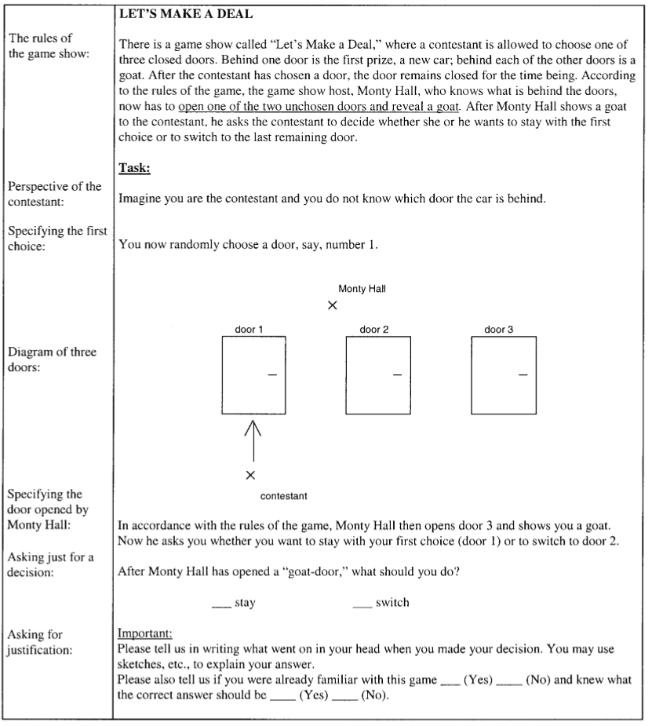

Control group instructions

## Appendix B: Experimental group instructions

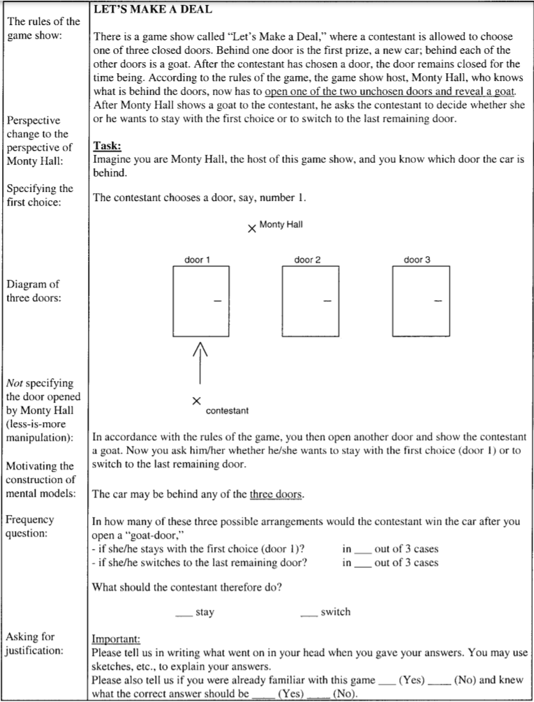

Experimental group instructions